# MIS 306 Data Analysis | Competition

NKE Stock Analysis - Group 3

Group Members:  
• Mert Özdemir  
• Berdan Berke Baş  
• Batuhan Karaköy  
• Yunus Emre Işıktan

2025-05-22

# Objective

This project analyzes Nike Inc. (NKE) stock performance (2007–2025) to identify patterns, build forecasting models, and generate investment insights. Key components include:

#### Data Exploration

- Analyze daily/weekly/monthly returns for trends and seasonality
- Compare weekday distributions (Monday–Friday) using statistical tests
- Examine volatility patterns and trading volume changes

#### Model Development

- Test stationarity and apply differencing when needed
- Fit multiple ARIMA configurations (ARIMA(1,1,1), ARIMA(2,1,1))
- Implement automated model selection via auto.arima
- Generate forecasts using optimal models

#### Validation & Insights

- Evaluate model fit through residual diagnostics
- Compare performance using AIC/BIC and error metrics
- Identify reliable patterns for trading strategies

Goal: Provide actionable intelligence about NKE’s price behavior and robust forecasting tools for investors.

# Visual Summaries

## Plot for opening, closing prices, high and low values and the volume

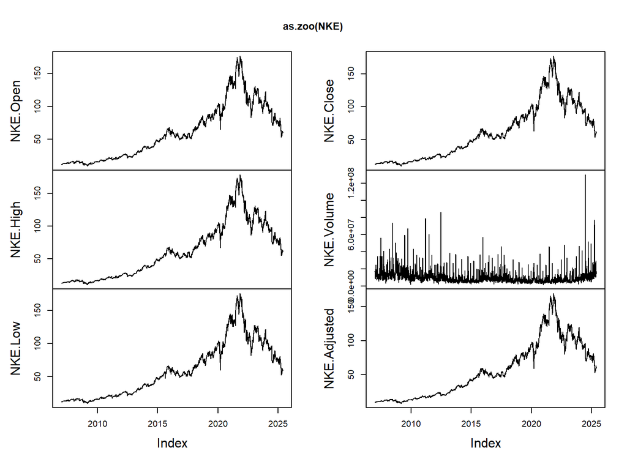

Nike’s stock exhibited strong growth from 2009 to 2021, peaking with high investor confidence. The post-2021 decline seen across all price indicators and the adjusted closing price suggests a broader market shift or internal performance issues. Trading volume spikes throughout the timeline point to periods of heightened interest, possibly tied to financial reports or economic events.

## Line Chart (2007 - 2025)

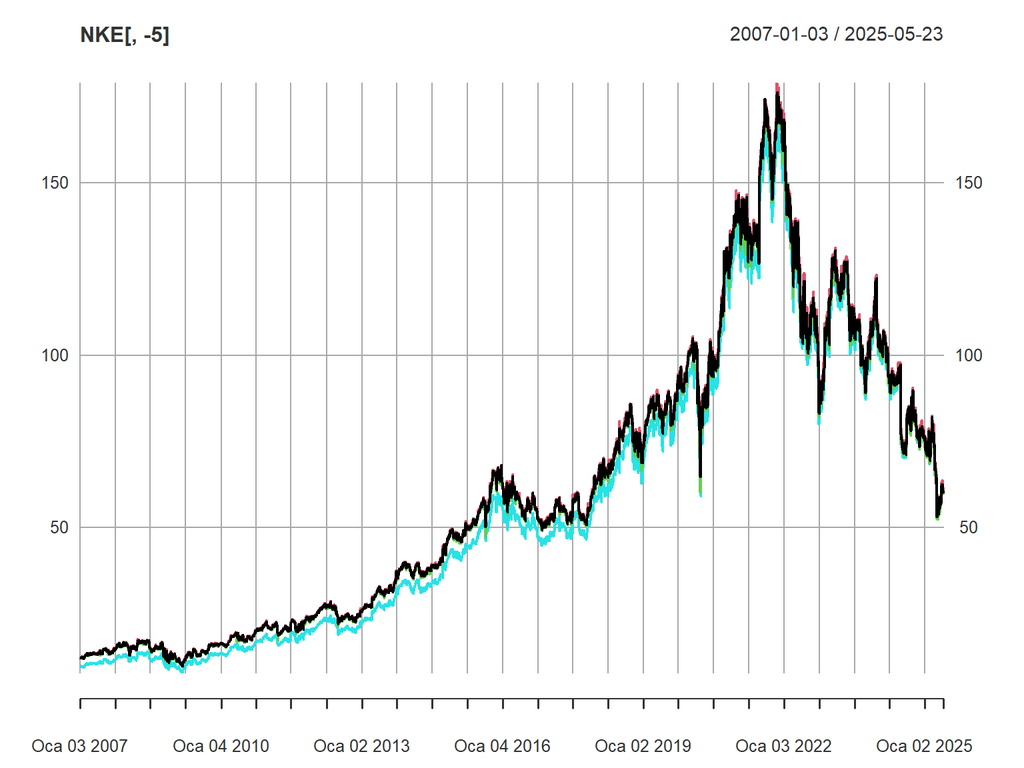

This chart shows the stock price of Nike (NKE) from January 2007 to May 2025. The price increased slowly until around 2013, then started to rise more quickly. It reached its highest point around the end of 2021, going above `$150`. After that, the price dropped a lot and continued to fall with some small increases in between. By 2025, the price is close to `$50`. Overall, the chart shows strong growth for many years, followed by a big decline after the peak.

# Visual Summaries

## Histogram: NKE returns (All Days | Monday | Friday)

```
## [1] "C"
```

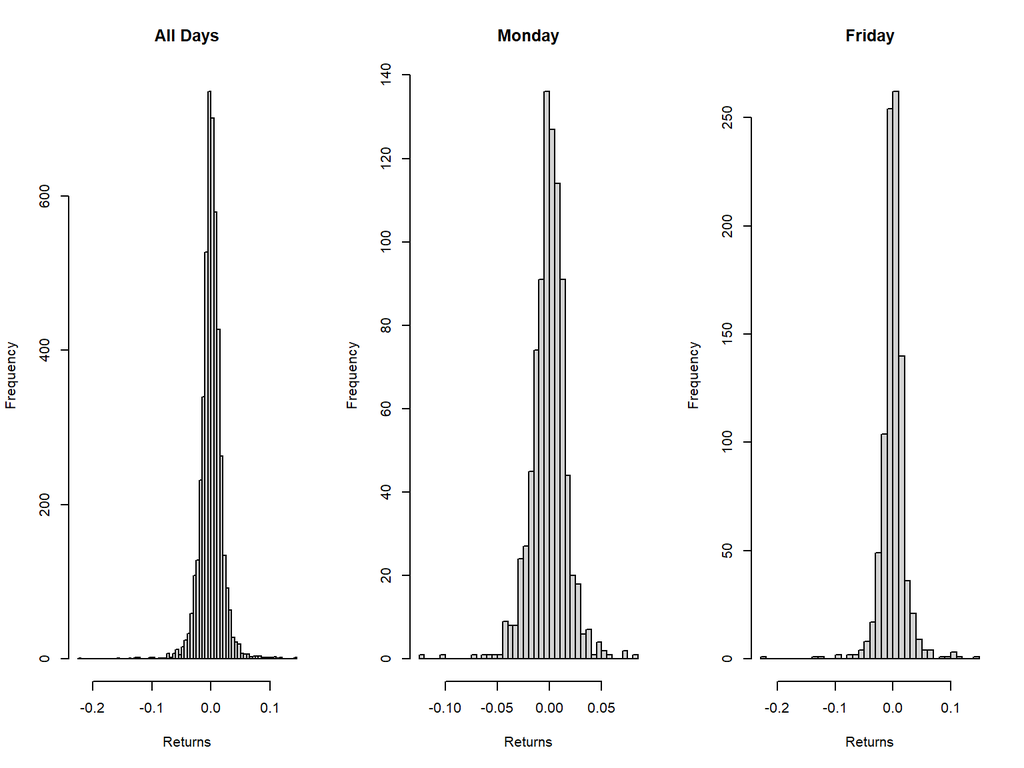

This figure shows the distribution of Nike’s daily returns, including all days, Mondays, and Fridays. All three histograms have a similar shape—most returns are close to zero, forming a sharp peak in the center. This means small daily changes are more common. Extreme values (both gains and losses) are rare but exist. Compared to Mondays, Friday returns seem slightly more spread out, which may suggest more market activity or news impact before the weekend. Overall, the returns appear to follow a normal-like distribution with slight differences by weekday.

## Empirical Cumulative Distribution of Fridays Return

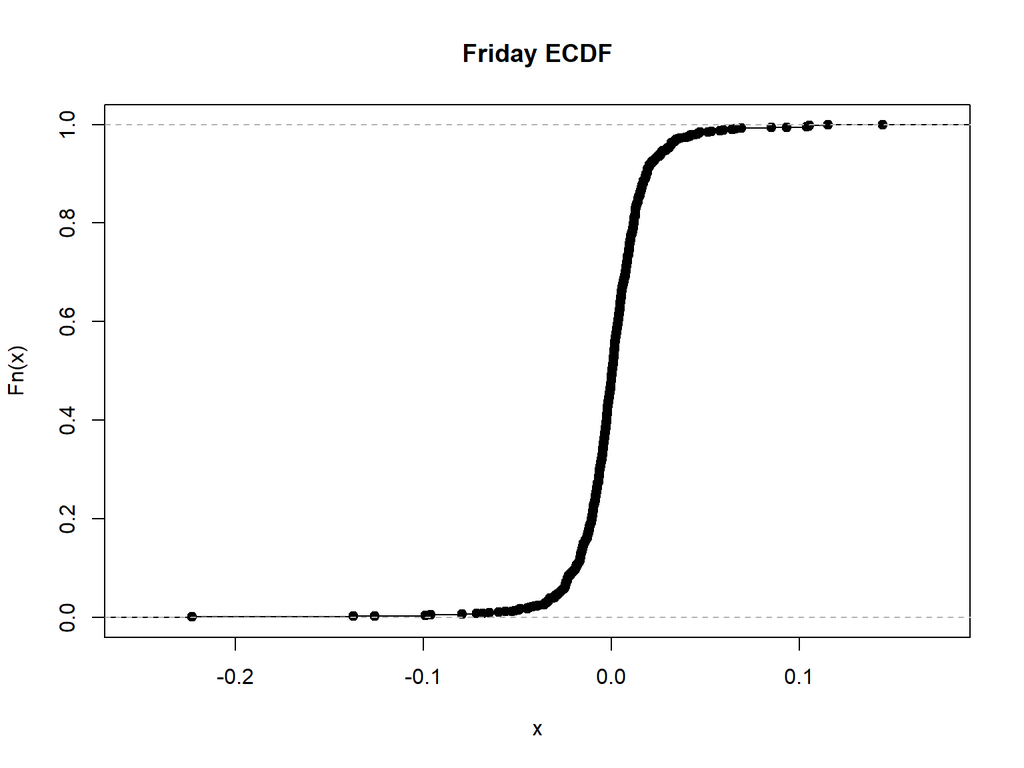

Most of the returns are between `-0.05` and `0.05`, with the curve rising steeply in that range. This means that small returns are the most common. The flat areas on both sides show rare extreme values, either losses or gains. Overall, the returns are centered around zero, and the shape of the curve suggests a normal-like distribution.

## Comparison of Empirical Cumulative Distributions of Monday (red) and Fridays (black) Return

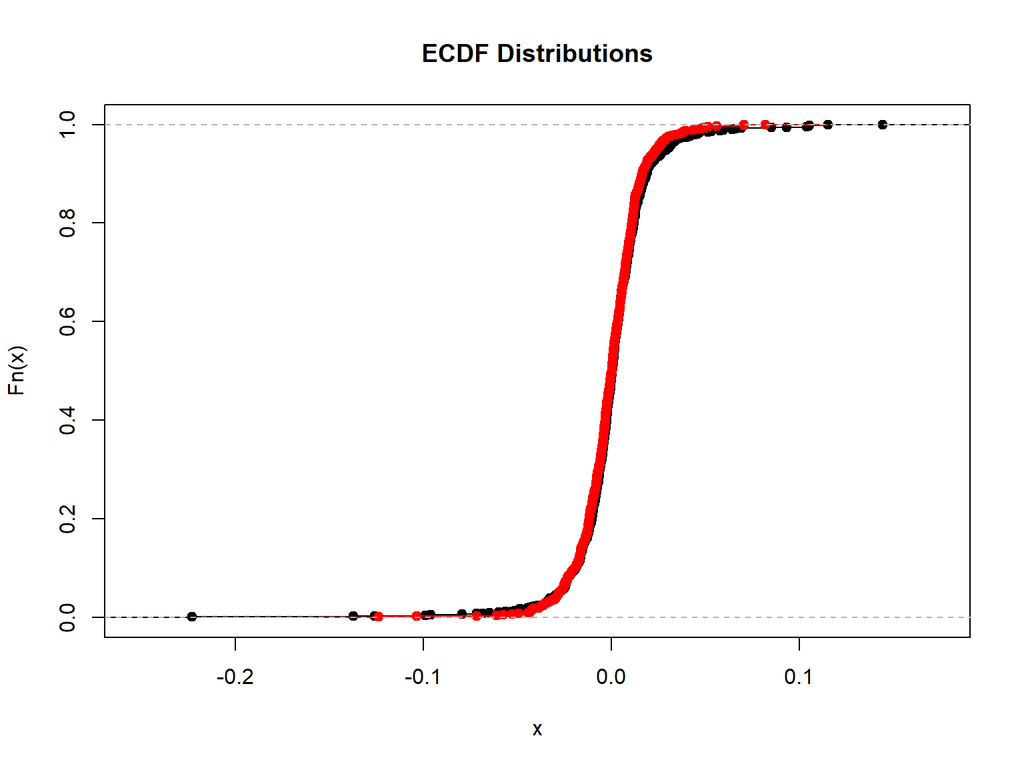

# Mean Returns

## Mean of the weekday returns

This table shows the average daily returns of Nike stock for each weekday. Monday has a small negative mean return (`-0.000448`), while all other days have positive mean returns. Thursday has the highest average return (`0.000759`), followed by Tuesday. This suggests that, on average, Nike performs slightly worse on Mondays and slightly better on Thursdays. Overall, the differences are small, but they show a possible weekday effect in returns.

```
##                    Mon     Tue      Wed      Thu      Fri
## Mean Returns -0.000448 0.00071 0.000392 0.000759 0.000499
```

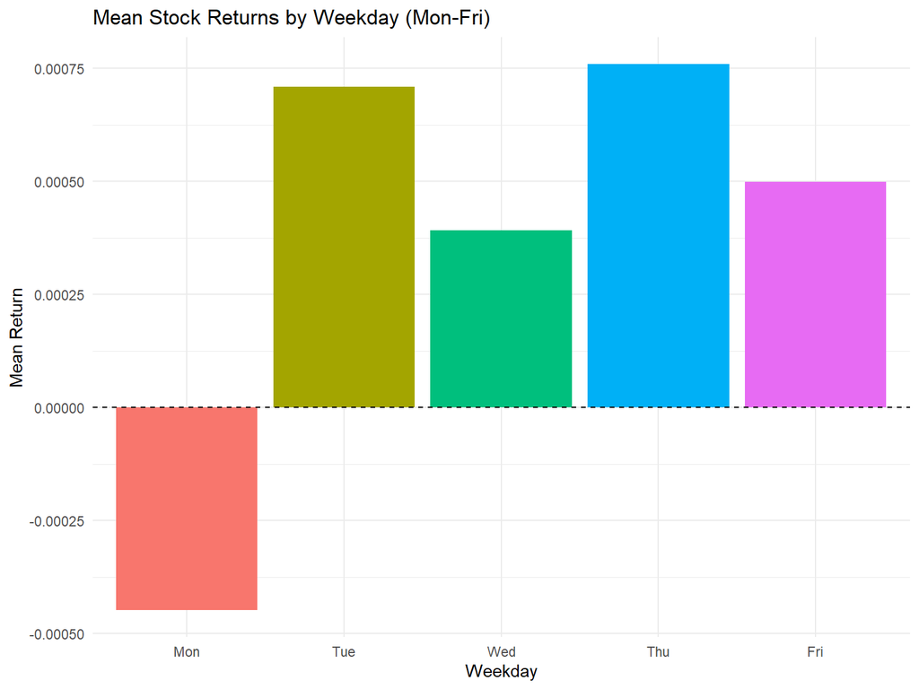

# NKE Monday Prices Line Chart

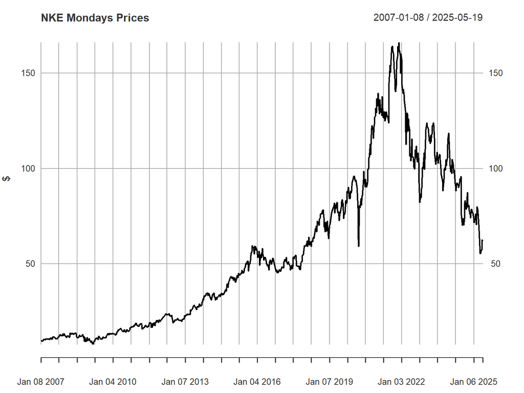

This chart shows Nike’s stock prices on Mondays from January 2007 to May 2025. The prices rose steadily until around late 2021, reaching a peak above `$150`. After that, the trend reversed, and the prices started to fall. By 2025, the price dropped to nearly $60. This shows a long period of growth followed by a strong decline, with Monday prices reflecting the overall market behavior.

# NKE Monday Prices Zoo

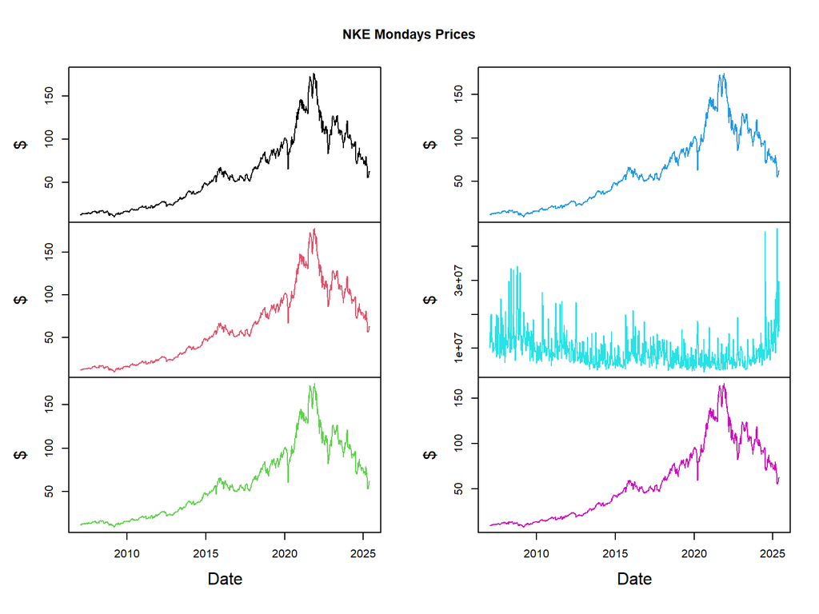

-Middle-right (cyan line): Volume. It shows the number of shares traded. There are many spikes, especially after 2020, which may indicate market reactions to news or events.

Overall, all price-related charts show growth until around 2021, then a decline. The volume chart shows trading activity became more volatile in recent years. Mondays clearly reflect the general stock trend of Nike.